12/13/2019

## Overview

## Research question

What are the most important and most difficult school subjects according to Jeopardy?

## Introduction

- Initial data investigation showed subject bias
- Prompted us to consider traditional school subjects
- Decided to compare “Jeopardy-based” education to public school education

## Methods: Joining Quizlet and Jeopardy data

- Created a dataframe of school subjects and related terms (from Quizlet)
- Converted all Jeopardy data and school subject data to lowercase and removed all special characters
- Randomly sampled 155 vocab terms from school subject data
- Used `inner_join` from the `dplyr` pacakage to match a the “question” to a specific vocab term
- Grouped the “questions” by subject

## Methods: Determining subject importance and difficulty using joined dataframe

- Discovered answer value changes after November 26, 2006 and decided to separate data into two categories
- Calculated number of occurances of each school subject (most important subject)
- Calculated average value of all “answers” for each school subject (most difficult subject)
- Graphed results using interactive heat map faceted by round and date

## Results: Heat map for round 1 and 2

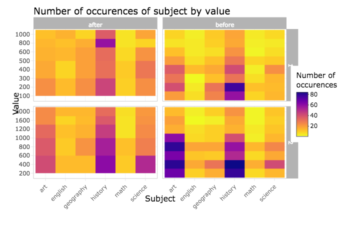

“Heat Map 3”

## Results: Daily Double heat map

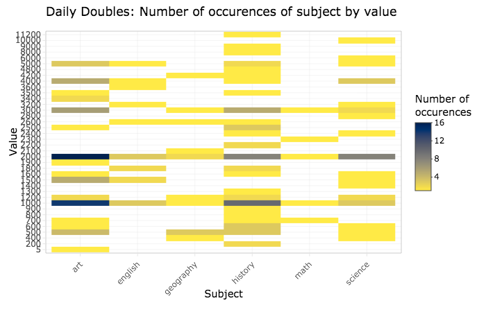

“Heat Map 4”

## Results: Summary Statistics before 11/26/2006

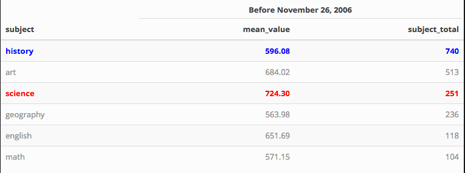

“before”

## Results: Summary statistics after 11/26/2006

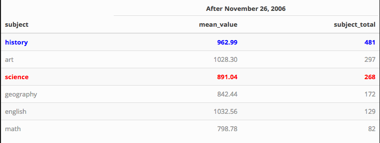

“after”

## Tutorial

## Overview: Approach in R

- The data for the subjects which, we would use to filter down the Jeopardy!, questions needed to be created and cleaned
- Initial Jeopardy! and subject data cleaning steps were taken to make the data more uniform (lowercase columns and values) removing special characters and numbers to facilitate our joining.
- The Jeopardy! and subject terms data were then joined, using `inner_join`, by the “question” column to only keep the rows which are in are in Jeopardy! and subjects terms data frames, and `inner_join` returns all columns.

## Overview: Approach in R

- For the creation of the subject data we had to utilize the `sample_n()` function from `dplyr` since we had more words for some subjects than others, and we chose to randomly select 155 words from each subject.
- Following our join of the two data frames we had to create one more column to depict the change in value of the question/answers that occurred after November 26, 2006.

## Packages

- packages for data filtering
  - library(readr)
  - library(dplyr)
  - library(stringr)
- package for tables
  - library(kableExtra)
- packages for plots
  - library(ggplot2)
  - library(viridis)
  - library(forcats)
  - library(plotly)
  - library(ggthemes)
  - library(RColorBrewer)

## Our Code

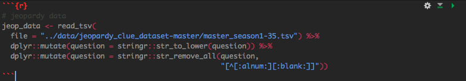

## Our Code

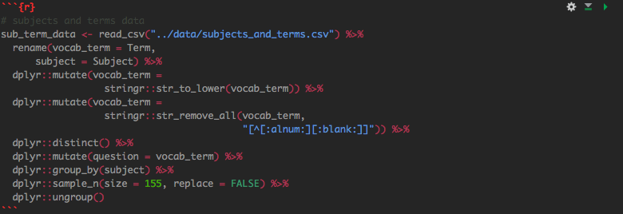

## Our Code

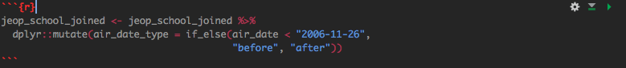

## Lessons learned

- .Rmd can be a curse and a blessing
  - Getting exactly what you think your .pdf should look like knitted isn’t always the easist thing.
- GitHub is a wonderful tool for collaborative work
  - Be very sure to inform others when you have pushed large amounts of changes…

## References

- Quizlet Inc. (2019). Quizlet. Retrieved from https://quizlet.com/
- R Programming for Research Retrieved from https://geanders.github.io/RProgrammingForResearch/
- Stack Exchange Retrieved from https://stackexchange.com/